# Scoring Project

## Step 5: Time-series cross-validation

The idea now is to run a time series analysis for each year between 2005 and 2024, using the logistic regression model to predict the likelihood of a company defaulting based on financial ratios, such as `WCTA`, `RETA`, `EBTA`, `TLTA`, `SLTA`.

For each iteration, we will split the dataset into training set (using all previous years) and a test set (using next year). Here, we train our model on the imbalanced dataset. We can see the proportions of each class in the training and test sets for each year, as well as an overview of model performance across all years.

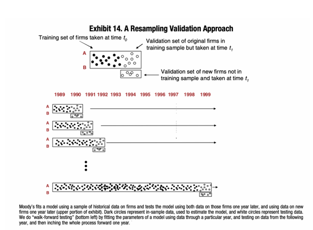

```r
years <- 2005:2024
results <- data.frame()

for (i in 1:(length(years) - 1)) {
  train_years <- years[1:i]
  test_year <- years[i + 1]

  train_data <- df_selected %>% filter(fyear %in% train_years)
  test_data <- df_selected %>% filter(fyear == test_year)

  # Check if we have value on the train and the test set
  if (nrow(train_data) == 0 | nrow(test_data) == 0) {
    next
  }

  model <- glm(Y_lopucki ~ WCTA + RETA + EBTA + TLTA + SLTA, data = train_data, family = binomial())

  predictions <- predict(model, newdata = test_data, type = "response")
  test_data$predicted_default <- ifelse(predictions > 0.5, 1, 0)


  if (all(test_data$predicted_default == 0, na.rm = TRUE) |
      all(test_data$predicted_default == 1, na.rm = TRUE)) {
    precision <- NA
    recall <- NA
    f1_score <- NA
  } else {
    confusion <- table(test_data$Y_lopucki, test_data$predicted_default)
    precision <- confusion[2, 2] / sum(confusion[, 2])
    recall <- confusion[2, 2] / sum(confusion[2, ])
    f1_score <- 2 * (precision * recall) / (precision + recall)
  }

  accuracy <- mean(test_data$predicted_default == test_data$Y_lopucki, na.rm = TRUE)

  results <- rbind(results, data.frame(test_year = test_year,
                                       accuracy = accuracy,
                                       precision = precision,
                                       recall = recall,
                                       f1_score = f1_score))
}

print(results)
```

```
   test_year  accuracy precision recall f1_score
1       2006 0.9937267        NA     NA       NA
2       2007 0.9879165        NA     NA       NA
3       2008 0.9801232        NA     NA       NA
4       2009 0.9897894        NA     NA       NA
5       2010 0.9945775        NA     NA       NA
6       2011 0.9905877        NA     NA       NA
7       2012 0.9934396        NA     NA       NA
8       2013 0.9935049        NA     NA       NA
9       2014 0.9908613        NA     NA       NA
10      2015 0.9865298        NA     NA       NA
11      2016 0.9894974        NA     NA       NA
12      2017 0.9920283        NA     NA       NA
13      2018 0.9792663        NA     NA       NA
14      2019 0.9723828        NA     NA       NA
15      2020 0.9894499        NA     NA       NA
16      2021 0.9567568        NA     NA       NA
17      2022 0.9228007        NA     NA       NA
18      2023 0.9170732        NA     NA       NA
19      2024 1.0000000        NA     NA       NA
```

```r
for (i in 1:(length(years) - 1)) {
  train_years <- years[1:i]
  test_year <- years[i + 1]

  train_data <- df_selected %>% filter(fyear %in% train_years)
  test_data <- df_selected %>% filter(fyear == test_year)

  if (nrow(train_data) == 0 | nrow(test_data) == 0) {
    next
  }

  cat("\nYear:", test_year, "\n")
  print(table(train_data$Y_lopucki) / nrow(train_data))
  print(table(test_data$Y_lopucki) / nrow(test_data))
}
```

```
Year: 2006

          0           1
0.996789727 0.003210273

          0           1
0.993726687 0.006273313

Year: 2007

          0           1
0.995300132 0.004699868

         0          1
0.98791651 0.01208349

Year: 2008

          0           1
0.993007391 0.006992609

         0          1
0.98012324 0.01987676

Year: 2009

          0           1
0.990141904 0.009858096

         0          1
0.98978941 0.01021059

Year: 2010

          0           1
0.990081253 0.009918747

          0           1
0.994577497 0.005422503

```

[output cut: 96 more lines]

```
Year: 2023

         0          1
0.98892011 0.01107989

         0          1
0.91707317 0.08292683

Year: 2024

         0          1
0.98868438 0.01131562

0
1
```

The following code also performs a time-series analisis of logistic regression models, by again evaluating each year’s performance. This code balances the training data using oversampling before fitting the logistic regression model, using the function `ovun.sumple()` with the `method="both"`, used to balance the classes by both oversampling the minority class and undersampling the majority

```r
results <- data.frame()

for (i in 1:(length(years) - 1)) {
  train_years <- years[1:i]
  test_year <- years[i + 1]

  train_data <- df_selected %>% filter(fyear %in% train_years)
  test_data <- df_selected %>% filter(fyear == test_year)

  if (nrow(train_data) == 0 | nrow(test_data) == 0) {
    next
  }


  if (length(unique(test_data$Y_lopucki)) < 2) {
    cat("Warning: Test data for year", test_year, "does not contain both classes.\n")
    next
  }

  # Balance the training data using oversampling
  train_data_balanced <- ovun.sample(Y_lopucki ~ ., data = train_data, method = "both")$data

  model <- glm(Y_lopucki ~ WCTA + RETA + EBTA + TLTA + SLTA, data = train_data_balanced, family = binomial())

  predictions <- predict(model, newdata = test_data, type = "response")
  test_data$predicted_default <- ifelse(predictions > 0.5, 1, 0)

  if (all(test_data$predicted_default == 0, na.rm = TRUE) |
      all(test_data$predicted_default == 1, na.rm = TRUE)) {
    precision <- NA
    recall <- NA
    f1_score <- NA
  } else {
    confusion <- table(test_data$Y_lopucki, test_data$predicted_default)
    precision <- confusion[2, 2] / sum(confusion[, 2])
    recall <- confusion[2, 2] / sum(confusion[2, ])
    f1_score <- 2 * (precision * recall) / (precision + recall)
  }

  accuracy <- mean(test_data$predicted_default == test_data$Y_lopucki, na.rm = TRUE)

  results <- rbind(results, data.frame(test_year = test_year,
                                       accuracy = accuracy,
                                       precision = ifelse(is.na(precision), 0, precision),
                                       recall = ifelse(is.na(recall), 0, recall),
                                       f1_score = ifelse(is.na(f1_score), 0, f1_score)))
}
print(results)
```

```
   test_year  accuracy   precision    recall   f1_score
1       2006 0.6854866 0.011290323 0.5675676 0.02214022
2       2007 0.6241304 0.017952450 0.5606061 0.03479079
3       2008 0.5923276 0.029425953 0.6100000 0.05614358
4       2009 0.5820038 0.016641452 0.6875000 0.03249631
5       2010 0.6070944 0.009719840 0.7083333 0.01917654
6       2011 0.5755280 0.015021459 0.6829268 0.02939633
7       2012 0.5775539 0.010479868 0.6785714 0.02064096
8       2013 0.5675743 0.009211284 0.6153846 0.01815088
9       2014 0.5613403 0.015615240 0.7575758 0.03059976
10      2015 0.5490699 0.023743017 0.8095238 0.04613297
11      2016 0.5476369 0.018003273 0.7857143 0.03520000
12      2017 0.5566873 0.014807502 0.8333333 0.02909796
13      2018 0.5688464 0.040476190 0.8717949 0.07736064
14      2019 0.5465639 0.051420839 0.8837209 0.09718670
15      2020 0.5568953 0.016835017 0.7142857 0.03289474
16      2021 0.5762162 0.060000000 0.6000000 0.10909091
17      2022 0.5421903 0.098484848 0.6046512 0.16938111
18      2023 0.5414634 0.126213592 0.7647059 0.21666667
```

# Practical 2 - Feature Engineering/Distance to Default

## Altman’s Score Revisited

The **Altman Z-Score** is a financial model developed by Edward Altman in 1968, used to predict the likelihood of a company going bankrupt within two years.

The following code includes data preprocessing and analysis steps. We create new variables: (i) Earning Growth (`earning_growth`), compared to previous period. (ii) size - size of the company, measured in total assests `at.` (iii) Return on Assets (`roa`): calculates the profitability of a company relative to its total assets, computed as a ratio of net income to total assets.

We also compute the Market equity to Book liabilities Ratio (`ME_BL`). This variable is computed as ratio of the common equity (`ceq`) to the long-term debt (`lt`). This provides a measure of a company’s financial leverage. We also apply some log transformation to some of the variables.

Next step is Winorization, when several variables (such as `size`, `at`, `Log_MEBL`, `ME_BL`, and `roa`) have limited extreme values (outliers). The winsorization process trims the values at the 20th and 80th percentiles, reducing the effect of extreme outliers on statistical analysis.

```r
company_all <- readRDS("wrds_data/company_all.rds")
compustat_all <- readRDS("wrds_data/compustat_all_light.rds")
```

```r
# We extract some variables from different datasets to create ratios that interest us, to include in the Altman's 2004 model
var_alt_age <- company_all %>%
  select(gvkey,incorp)

var_alt_dltt <- compustat_all %>%
  select(gvkey,dltt, xrd)

var_alt <- var_alt_age %>%
  left_join(var_alt_dltt, by = "gvkey")

df_selected$at <- data$at
df_selected$gvkey <- final_data$gvkey
final_combined <- df_selected %>%
  left_join(var_alt, by = "gvkey", relationship = "many-to-many")
```

```r
# We create the variables earnings_growth, size and roa
# earnings growth measures growth in earnings or net income
# size is the size of the company, measured by at, it's total assets
# roa measures profitability relative to total assets

final_combined <- final_combined %>%
  mutate(earnings_growth = (ni - lag(ni) / lag(ni)), size = at, roa = ni / at)
```

```r
# Compute ME_BL (Market Equity to Book Liabilities Ratio)
final_combined <- final_combined %>%
  mutate(
    ME_BL = ceq / lt
  )

# Log-transform RETA and EBTA and ME_BL
final_combined <- final_combined %>%
  mutate(
    Log_RETA = ifelse(RETA < 1, -log(1 - RETA), NA),
    Log_EBTA = ifelse(EBTA < 1, -log(1 - EBTA), NA),
    Log_MEBL = 1 + log(ME_BL)
  )
```

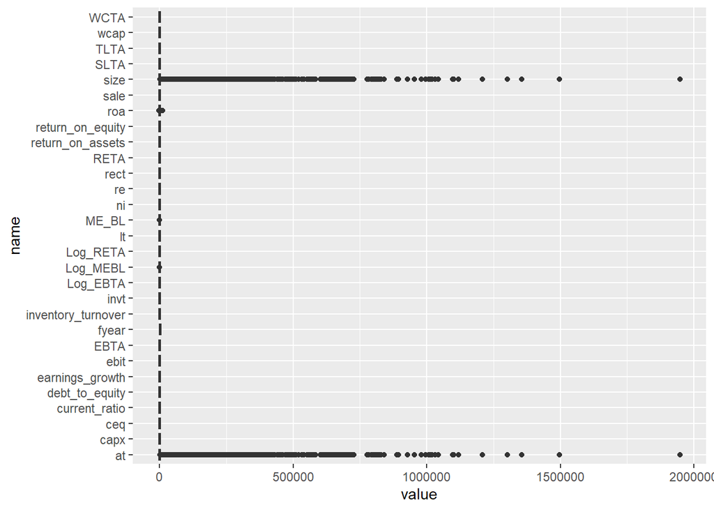

```r
df_final_combined <- final_combined %>% select(where(is.numeric) & !c(xrd,dltt,incorp, Y_lopucki))

df_final_combined %>%
  pivot_longer(where(is.numeric)) %>%
  ggplot(aes(x = name, y = value)) +
  geom_boxplot() +
  coord_flip()
```

```r
# Apply winsorization
final_combined <- final_combined %>%
  mutate(
    size = winsorize(size,0.2,0.8),
    at = winsorize(at,0.2,0.8),
    Log_MEBL = winsorize(Log_MEBL,0.2,0.8),
    ME_BL = winsorize(ME_BL,0.2,0.8),
    roa = winsorize(roa,0.2,0.8)
  )
```

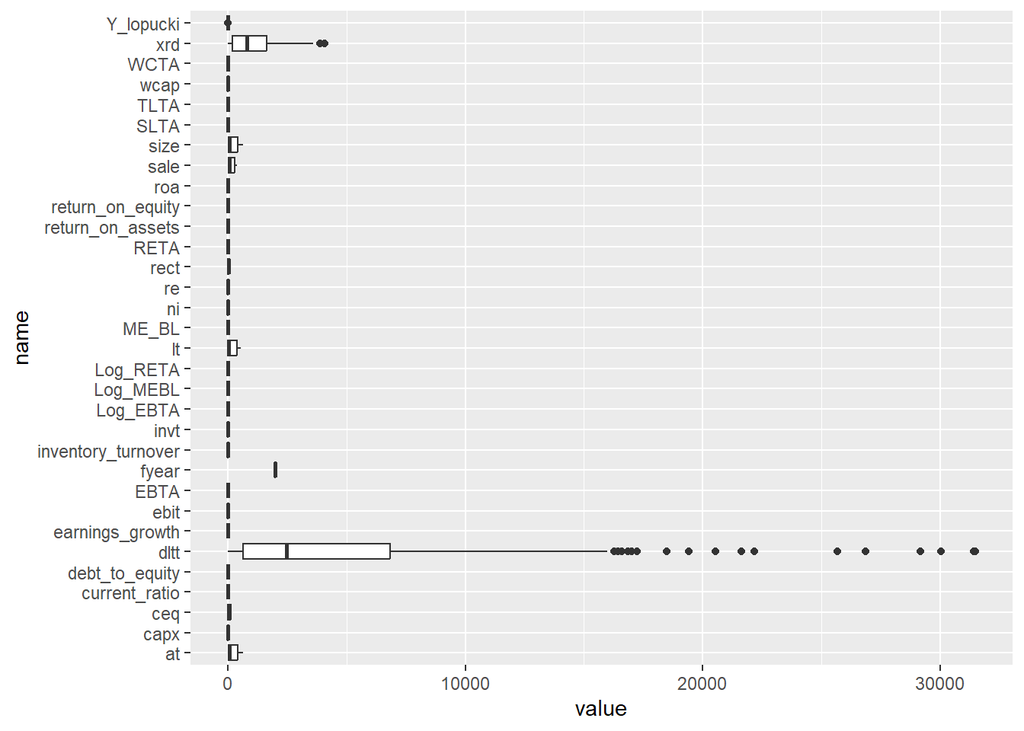

```r
final_combined %>%
  pivot_longer(where(is.numeric)) %>%
  ggplot(aes(x = name, y = value)) +
  geom_boxplot() +
  coord_flip()
```

```r
selected_data <- final_combined %>% select(WCTA, RETA, EBTA, TLTA)
analyze_na(selected_data)$data
```

```
[1] "Missing Values Analysis -"
     Column NA_Count NA_Percentage
WCTA   WCTA        0             0
RETA   RETA        0             0
EBTA   EBTA        0             0
TLTA   TLTA        0             0
```

```
     Column NA_Count NA_Percentage
WCTA   WCTA        0             0
RETA   RETA        0             0
EBTA   EBTA        0             0
TLTA   TLTA        0             0
```

```r
cor_matrix <- cor(selected_data)
print(cor_matrix)
```

```
           WCTA       RETA        EBTA        TLTA
WCTA  1.0000000  0.1428867  0.11501859 -0.49564024
RETA  0.1428867  1.0000000  0.56605714 -0.18042467
EBTA  0.1150186  0.5660571  1.00000000 -0.08981647
TLTA -0.4956402 -0.1804247 -0.08981647  1.00000000
```

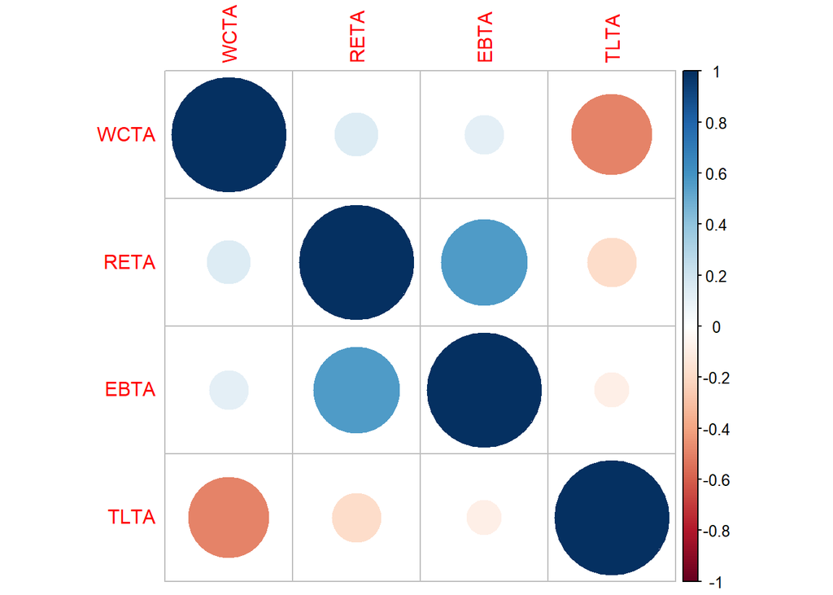

```r
corrplot(cor_matrix)
```

The following step will be computing two Altman models, one from 1968 and the other one from 2004. Both models aim to predict bankruptcy, but differ in their structure, especially the financial ratios they use. But for sure the Altman (2004) model is a more comprehensive and modern version of the Altman (1968) model.

```r
# Fit the Altman (1968) model
altman_1968 <- glm(Y_lopucki ~ WCTA + RETA + EBTA + TLTA + SLTA, data = final_combined, family = binomial)
summary(altman_1968)
```

```
Call:
glm(formula = Y_lopucki ~ WCTA + RETA + EBTA + TLTA + SLTA, family = binomial,
    data = final_combined)

Coefficients:
            Estimate Std. Error z value Pr(>|z|)
(Intercept) -6.45318    0.09541 -67.638  < 2e-16 ***
WCTA        -0.83700    0.13488  -6.205 5.46e-10 ***
RETA        -0.30282    0.06459  -4.689 2.75e-06 ***
EBTA        -3.33297    0.27192 -12.257  < 2e-16 ***
TLTA         2.57893    0.11672  22.094  < 2e-16 ***
SLTA         0.07479    0.03382   2.211    0.027 *
---
Signif. codes:  0 '***' 0.001 '**' 0.01 '*' 0.05 '.' 0.1 ' ' 1

(Dispersion parameter for binomial family taken to be 1)

    Null deviance: 31392  on 351705  degrees of freedom
Residual deviance: 29845  on 351700  degrees of freedom
AIC: 29857

Number of Fisher Scoring iterations: 8
```

In the Altman 1968 model, all predictors are statistically significant (p < 0.05), highlighting their importance in explaining default risk.

The coefficient for WCTA is -0.83700, indicating that higher working capital relative to total assets reduces the likelihood of default. This emphasizes the importance of liquidity, as companies with stronger liquidity are better able to manage their financial obligations and reduce the risk of distress.

The coefficient for RETA is -0.30282, suggesting that higher retained earnings relative to total assets decrease the likelihood of default. Retained earnings reflect accumulated profitability and financial stability, making such companies less vulnerable to financial distress.

EBTA has the most negative coefficient (-3.33297), highlighting the critical role of profitability. Companies with higher earnings before taxes relative to total assets are significantly less likely to default, underlining the importance of operational profitability in reducing financial vulnerability.

In contrast, TLTA has a positive coefficient of 2.57893, suggesting that higher leverage (liabilities relative to assets) increases the likelihood of default. This is consistent with financial theory, where excessive debt levels heighten financial vulnerability and increase default risk.

Finally, the coefficient for SLTA is 0.07479, a small positive value, indicating that higher sales efficiency slightly increases the likelihood of default. This might reflect that aggressive sales strategies, without adequate financial management, could lead to liquidity constraints or overextension.

```r
# Fit the Altman (2004) model
altman_2004 <- glm(Y_lopucki ~ WCTA + Log_RETA + Log_EBTA + Log_MEBL + earnings_growth + roa + size, data = final_combined, family = binomial)
summary(altman_2004)
```

```
Call:
glm(formula = Y_lopucki ~ WCTA + Log_RETA + Log_EBTA + Log_MEBL +
    earnings_growth + roa + size, family = binomial, data = final_combined)

Coefficients:
                  Estimate Std. Error  z value Pr(>|z|)
(Intercept)     -4.805e+00  3.872e-02 -124.108  < 2e-16 ***
WCTA            -1.002e+00  1.284e-01   -7.804 5.99e-15 ***
Log_RETA        -3.084e-01  8.266e-02   -3.731 0.000191 ***
Log_EBTA        -1.573e+00  3.037e-01   -5.182 2.20e-07 ***
Log_MEBL        -7.989e-01  4.290e-02  -18.626  < 2e-16 ***
earnings_growth -1.023e-01  4.757e-03  -21.508  < 2e-16 ***
roa             -9.290e-01  8.408e-01   -1.105 0.269202
size             1.197e-03  8.208e-05   14.583  < 2e-16 ***
---
Signif. codes:  0 '***' 0.001 '**' 0.01 '*' 0.05 '.' 0.1 ' ' 1

(Dispersion parameter for binomial family taken to be 1)

    Null deviance: 31309  on 351365  degrees of freedom
Residual deviance: 29084  on 351358  degrees of freedom
  (340 observations effacées parce que manquantes)
AIC: 29100

Number of Fisher Scoring iterations: 8
```

In the Altman 2004 model, most predictors remain statistically significant, except for ROA, which has a p-value of 0.269 and is not statistically significant in this model.

The coefficient for WCTA is -1.00200, reaffirming that stronger liquidity reduces the likelihood of default. Companies with higher working capital relative to total assets are better equipped to meet their obligations and avoid distress.

Log_EBTA has a coefficient of -1.57340, further emphasizing the role of profitability in mitigating default risk. Higher earnings before taxes relative to total assets are associated with a lower likelihood of financial distress.

```
[1] "Missing Values Analysis -"
                         Column NA_Count NA_Percentage
earnings_growth earnings_growth      340    0.09667165
WCTA                       WCTA        0    0.00000000
Log_RETA               Log_RETA        0    0.00000000
Log_EBTA               Log_EBTA        0    0.00000000
Log_MEBL               Log_MEBL        0    0.00000000
roa                         roa        0    0.00000000
size                       size        0    0.00000000
```

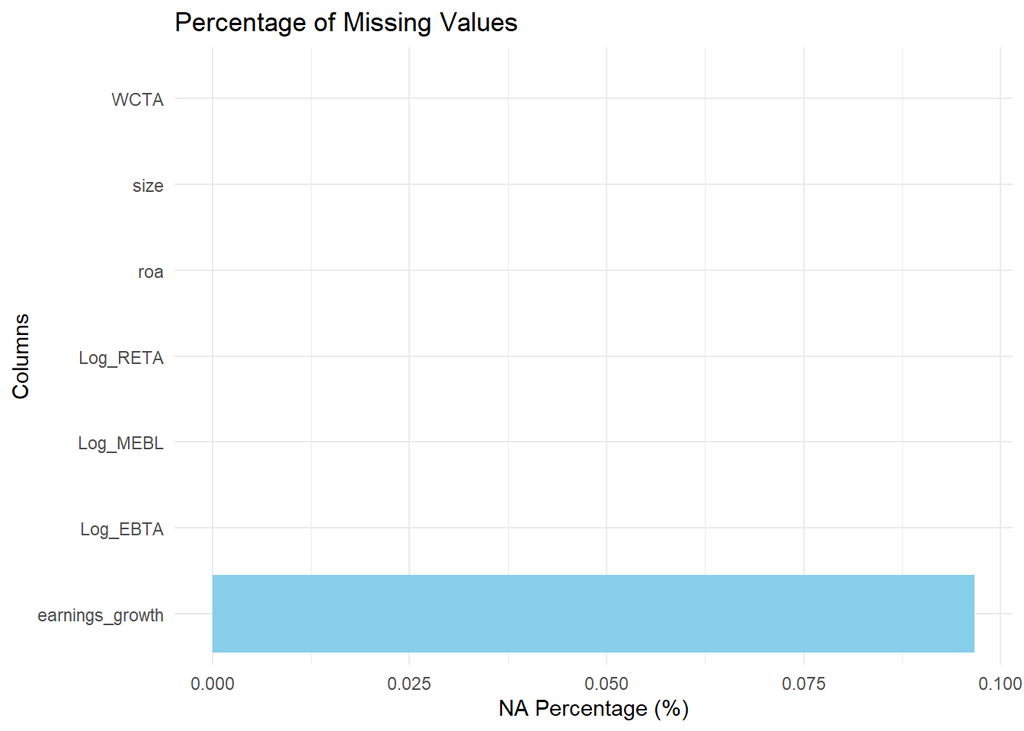

```r
selected_data <- final_combined %>% select(WCTA, Log_RETA, Log_EBTA, Log_MEBL, earnings_growth, roa, size)
analyze_na(selected_data)
```

```r
mean_earnings_growth <- mean(final_combined$earnings_growth, na.rm = TRUE)
final_combined <- final_combined %>%
        mutate(earnings_growth = replace(earnings_growth, is.na(earnings_growth), mean_earnings_growth))
selected_data$earnings_growth <- final_combined$earnings_growth
```

The low number of missing values in the variable `earnings_growth` allows us to perform a simple imputation using the mean. When the proportion of missing data is minimal, this method is widely accepted as it preserves the overall distribution of the data without introducing significant bias.

```r
analyze_na(selected_data)$data
```

```
[1] "Missing Values Analysis -"
                         Column NA_Count NA_Percentage
WCTA                       WCTA        0             0
Log_RETA               Log_RETA        0             0
Log_EBTA               Log_EBTA        0             0
Log_MEBL               Log_MEBL        0             0
earnings_growth earnings_growth        0             0
roa                         roa        0             0
size                       size        0             0
```

```
                         Column NA_Count NA_Percentage
WCTA                       WCTA        0             0
Log_RETA               Log_RETA        0             0
Log_EBTA               Log_EBTA        0             0
Log_MEBL               Log_MEBL        0             0
earnings_growth earnings_growth        0             0
roa                         roa        0             0
size                       size        0             0
```

```r
analyze_na(selected_data)$data
```

```
[1] "Missing Values Analysis -"
                         Column NA_Count NA_Percentage
WCTA                       WCTA        0             0
Log_RETA               Log_RETA        0             0
Log_EBTA               Log_EBTA        0             0
Log_MEBL               Log_MEBL        0             0
earnings_growth earnings_growth        0             0
roa                         roa        0             0
size                       size        0             0
```

```
                         Column NA_Count NA_Percentage
WCTA                       WCTA        0             0
Log_RETA               Log_RETA        0             0
Log_EBTA               Log_EBTA        0             0
Log_MEBL               Log_MEBL        0             0
earnings_growth earnings_growth        0             0
roa                         roa        0             0
size                       size        0             0
```

```r
cor_matrix <- cor(selected_data)
print(cor_matrix)
```

```
                       WCTA  Log_RETA  Log_EBTA      Log_MEBL earnings_growth
WCTA             1.00000000 0.1659731 0.1186118  0.4421727000   -0.0252978167
Log_RETA         0.16597310 1.0000000 0.5621962  0.2288522103    0.4295073585
Log_EBTA         0.11861177 0.5621962 1.0000000  0.1131882151    0.4864594748
Log_MEBL         0.44217270 0.2288522 0.1131882  1.0000000000   -0.0001143464
earnings_growth -0.02529782 0.4295074 0.4864595 -0.0001143464    1.0000000000
roa              0.21835215 0.5138442 0.6875956  0.2871228632    0.4585039332
size            -0.22917445 0.2245658 0.1779637 -0.3307869767    0.5406301252
                        roa        size
WCTA             0.21835215 -0.22917445
Log_RETA         0.51384418  0.22456577
Log_EBTA         0.68759560  0.17796372
Log_MEBL         0.28712286 -0.33078698
earnings_growth  0.45850393  0.54063013
roa              1.00000000 -0.02793884
size            -0.02793884  1.00000000
```

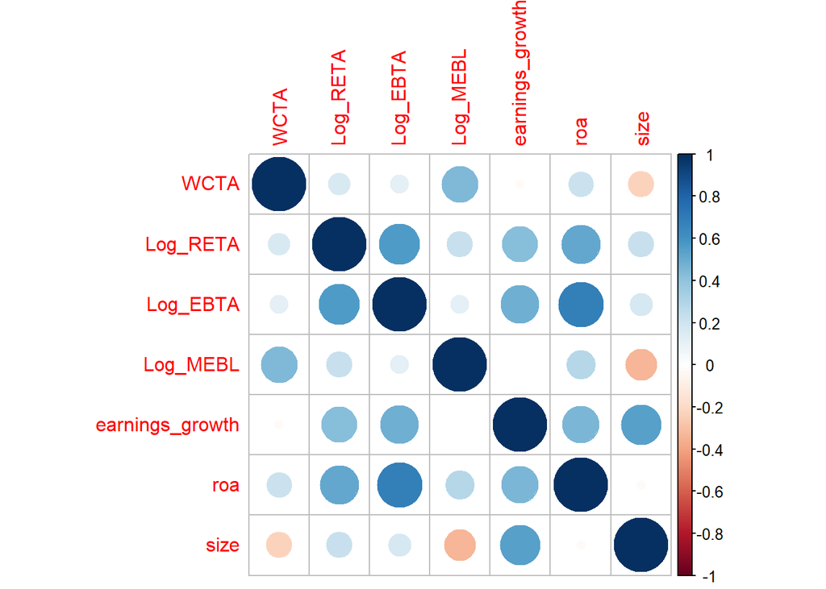

```r
corrplot(cor_matrix)
```

```r
# Fit the Altman (2004) model
altman_2004 <- glm(Y_lopucki ~ WCTA + Log_RETA + Log_EBTA + Log_MEBL + earnings_growth + roa + size, data = final_combined, family = binomial)
summary(altman_2004)
```

```
Call:
glm(formula = Y_lopucki ~ WCTA + Log_RETA + Log_EBTA + Log_MEBL +
    earnings_growth + roa + size, family = binomial, data = final_combined)

Coefficients:
                  Estimate Std. Error  z value Pr(>|z|)
(Intercept)     -4.801e+00  3.866e-02 -124.205  < 2e-16 ***
WCTA            -1.005e+00  1.282e-01   -7.840 4.50e-15 ***
Log_RETA        -3.117e-01  8.254e-02   -3.776 0.000159 ***
Log_EBTA        -1.581e+00  3.034e-01   -5.210 1.89e-07 ***
Log_MEBL        -7.941e-01  4.276e-02  -18.573  < 2e-16 ***
earnings_growth -1.016e-01  4.748e-03  -21.389  < 2e-16 ***
roa             -1.028e+00  8.400e-01   -1.224 0.220949
size             1.192e-03  8.206e-05   14.529  < 2e-16 ***
---
Signif. codes:  0 '***' 0.001 '**' 0.01 '*' 0.05 '.' 0.1 ' ' 1

(Dispersion parameter for binomial family taken to be 1)

    Null deviance: 31392  on 351705  degrees of freedom
Residual deviance: 29171  on 351698  degrees of freedom
AIC: 29187

Number of Fisher Scoring iterations: 8
```

```r
AIC(altman_1968)
```

```
[1] 29857.39
```

```r
AIC(altman_2004)
```

```
[1] 29186.75
```

```r
BIC(altman_1968)
```

```
[1] 29922.01
```

```r
BIC(altman_2004)
```

```
[1] 29272.92
```

Predictive accuracy.

```r
# Set seed for reproducibility
set.seed(123)

# Create training and testing indices based on an 80-20 split of the target variable Y
train_index <- createDataPartition(final_combined$Y_lopucki, p = 0.8, list = FALSE)

# Split the data into training and testing sets
# 80% of the data for training
train <- final_combined[train_index, ]
# Remaining 20% for testing
test <- final_combined[-train_index, ]

# Predictions using the Altman 1968 model
# Predict probabilities for test data
pred_1968 <- predict(altman_1968, newdata = test, type = "response")
# Convert probabilities to binary classes (threshold = 0.5)
class_1968 <- ifelse(pred_1968 > 0.5, 1, 0)

# Predictions using the Altman 2004 model
# Predict probabilities for test data
pred_2004 <- predict(altman_2004, newdata = test, type = "response")
# Convert probabilities to binary classes (threshold = 0.5)
class_2004 <- ifelse(pred_2004 > 0.5, 1, 0)

# Generate confusion matrices for the Altman 1968 model
# Compare predicted vs. actual values for Altman 1968
confusion_1968 <- confusionMatrix(factor(class_1968), factor(test$Y_lopucki))
# Generate confusion matrices for the Altman 2004 model
# Compare predicted vs. actual values for Altman 2004
confusion_2004 <- confusionMatrix(factor(class_2004), factor(test$Y_lopucki))
# Display confusion matrix results for the Altman 1968 model
confusion_1968
```

```
Confusion Matrix and Statistics

          Reference
Prediction     0     1
         0 69804   537
         1     0     0

               Accuracy : 0.9924
                 95% CI : (0.9917, 0.993)
    No Information Rate : 0.9924
    P-Value [Acc > NIR] : 0.5115

                  Kappa : 0

 Mcnemar's Test P-Value : <2e-16

            Sensitivity : 1.0000
            Specificity : 0.0000
         Pos Pred Value : 0.9924
         Neg Pred Value :    NaN
             Prevalence : 0.9924
         Detection Rate : 0.9924
   Detection Prevalence : 1.0000
      Balanced Accuracy : 0.5000

       'Positive' Class : 0
```

```r
# Display confusion matrix results for the Altman 2004 model
confusion_2004
```

```
Confusion Matrix and Statistics

          Reference
Prediction     0     1
         0 69804   537
         1     0     0

               Accuracy : 0.9924
                 95% CI : (0.9917, 0.993)
    No Information Rate : 0.9924
    P-Value [Acc > NIR] : 0.5115

                  Kappa : 0

 Mcnemar's Test P-Value : <2e-16

            Sensitivity : 1.0000
            Specificity : 0.0000
         Pos Pred Value : 0.9924
         Neg Pred Value :    NaN
             Prevalence : 0.9924
         Detection Rate : 0.9924
   Detection Prevalence : 1.0000
      Balanced Accuracy : 0.5000

       'Positive' Class : 0
```

```r
levels_combined_1968 <- union(levels(factor(class_1968)), levels(factor(test$Y_lopucki)))
levels_combined_2004 <- union(levels(factor(class_2004)), levels(factor(test$Y_lopucki)))


# Refactor both variables to have the same levels
class_1968 <- factor(class_1968, levels = levels_combined_1968)
test$Y_lopucki <- factor(test$Y_lopucki, levels = levels_combined_1968)


# Calculate the confusion matrix
confusion_1968 <- confusionMatrix(class_1968, test$Y_lopucki)

# Display the confusion matrix
print(confusion_1968)
```

```
Confusion Matrix and Statistics

          Reference
Prediction     0     1
         0 69804   537
         1     0     0

               Accuracy : 0.9924
                 95% CI : (0.9917, 0.993)
    No Information Rate : 0.9924
    P-Value [Acc > NIR] : 0.5115

                  Kappa : 0

 Mcnemar's Test P-Value : <2e-16

            Sensitivity : 1.0000
            Specificity : 0.0000
         Pos Pred Value : 0.9924
         Neg Pred Value :    NaN
             Prevalence : 0.9924
         Detection Rate : 0.9924
   Detection Prevalence : 1.0000
      Balanced Accuracy : 0.5000

       'Positive' Class : 0
```

```r
class_2004 <- factor(class_2004, levels = levels_combined_2004)
test$Y_lopucki <- factor(test$Y_lopucki, levels = levels_combined_2004)

confusion_2004 <- confusionMatrix(class_2004, test$Y_lopucki)

# Display the confusion matrix
print(confusion_2004)
```

```
Confusion Matrix and Statistics

          Reference
Prediction     0     1
         0 69804   537
         1     0     0

               Accuracy : 0.9924
                 95% CI : (0.9917, 0.993)
    No Information Rate : 0.9924
    P-Value [Acc > NIR] : 0.5115

                  Kappa : 0

 Mcnemar's Test P-Value : <2e-16

            Sensitivity : 1.0000
            Specificity : 0.0000
         Pos Pred Value : 0.9924
         Neg Pred Value :    NaN
             Prevalence : 0.9924
         Detection Rate : 0.9924
   Detection Prevalence : 1.0000
      Balanced Accuracy : 0.5000

       'Positive' Class : 0
```

**Class 0**: Represents firms that are **financially stable or healthy**.

**Class 1**: Represents firms that are **financially distressed or at risk of bankruptcy**.

- **Altman 1968 :**

**Accuracy**: **99.24% :** Almost all predictions align with the majority class (Class 0).

**No Information Rate (NIR)**: **99.24% :** This is the accuracy we’d get by always predicting the majority class (Class 0).

**Kappa**: **0 :** Indicates no improvement over random chance (the model fails to classify Class 1 entirely).

**Sensitivity (Class 0)**: **1.0000 :** The model perfectly predicts Class 0.

**Specificity (Class 1)**: **0.0000 :** The model fails to predict any of Class 1.

**Balanced Accuracy**: **0.5000 :** Average of sensitivity and specificity, poor balance in predictions.

- **Altman 2004 :**

**Accuracy**: **99.24% :** Almost all predictions align with the majority class (Class 0).

**No Information Rate (NIR)**: **99.24% :** Always predicting Class 0 would yield this accuracy.

**Kappa**: **0 :** Again, no meaningful differentiation between classes.

**Sensitivity (Class 0)**: **1.0000 :** Perfect prediction for Class 0.

**Specificity (Class 1)**: **0.0000 :** Class 1 is completely missed.

**Balanced Accuracy**: **0.5000 :** Reflects the lack of prediction balance.

ROC curve and AUC.

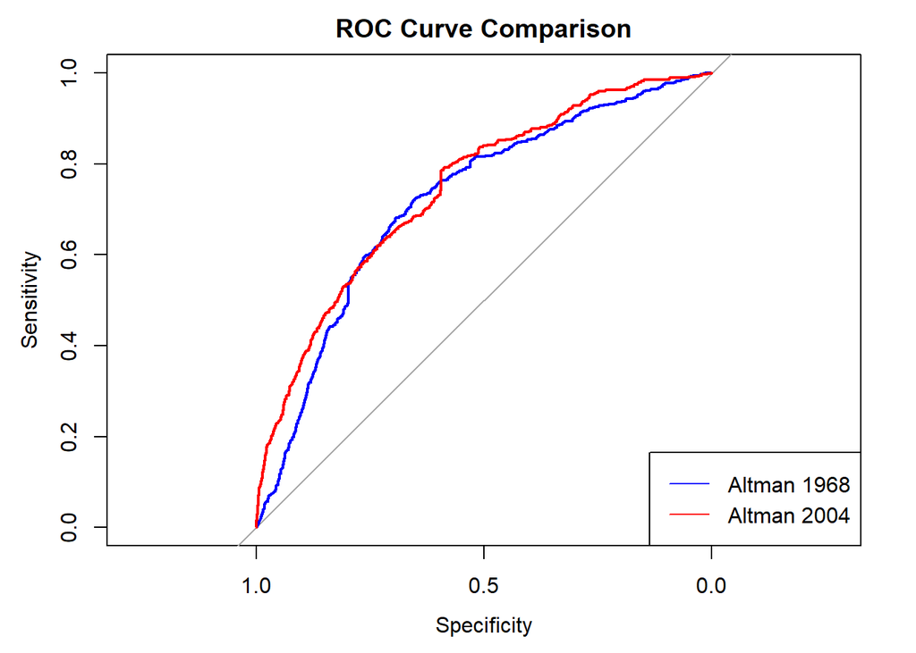

```r
# ROC for 1968 model
roc_1968 <- roc(test$Y_lopucki, pred_1968)
auc_1968 <- auc(roc_1968)

# ROC for 2004 model
roc_2004 <- roc(test$Y_lopucki, pred_2004)
auc_2004 <- auc(roc_2004)

# Plot ROC curves
plot(roc_1968, col = "blue", main = "ROC Curve Comparison")
lines(roc_2004, col = "red")
legend("bottomright", legend = c("Altman 1968", "Altman 2004"), col = c("blue", "red"), lty = 1)
```

```r
# Compare AUC values
auc_1968
```

```
Area under the curve: 0.7197
```

```r
auc_2004
```

```
Area under the curve: 0.7446
```

McFradden’s R²: this metric indicates how well the model explains variability in the dependent variable.

- **R² ≈ 0.2-0.4**: A good fit for logistic regression models.
- **R² ≈ 0.5-0.6**: A very good fit.
- **R² > 0.6**: An excellent fit (rare in logistic regression).

```r
# McFadden's R²
1 - (logLik(altman_1968) / logLik(glm(Y_lopucki ~ 1, data = final_combined, family = binomial)))
```

```
'log Lik.' 0.04928146 (df=6)
```

```r
1 - (logLik(altman_2004) / logLik(glm(Y_lopucki ~ 1, data = final_combined, family = binomial)))
```

```
'log Lik.' 0.07077186 (df=8)
```

## The Merton Model (1974)

The **Merton model**, developed by Robert C. Merton in 1974 is another method used to estimate the default risk of a company. It is based on the structural approach to credit risk, where the value of a firm’s equity is treated as a call option on its assets.

We need to estimate the Distance to Default (DtD) and Default probability (PD) of companies. We start by calculating key financial metrics, and using both a naive and iterative approach we compute DtD and DP. We followed methodology described by Vassalou, 2004 method. The output shows us a comparison of the results from these two methods and visualizes the differences.

```r
data <- df_selected
data$gvkey <- final_data$gvkey
data$datadate <- final_data$datadate
data$ceq <- df_clean$ceq
data$lct <- df_clean$lct

treasury_1Y <- readRDS("wrds_data/treasury_1Y.rds")

data <- data %>%
  left_join(treasury_1Y %>%
              mutate(r = VALUE / 100) %>%
              dplyr::select(-VALUE),
            by = c("datadate" = "DATE")) %>%
  fill(r, .direction = "downup")

# Compute Default Point (DP) based on Vassalou (2004)
data <- data %>%
  mutate(
    DP = lct + 0.5 * lt, # Short-term debt + half of long-term debt
    E = ceq,             # Equity value from column 'ceq'
    D = DP               # Using DP as debt proxy
  )
```

```
[1] "Missing Values Analysis -"
                               Column NA_Count NA_Percentage
inventory_turnover inventory_turnover        0             0
current_ratio           current_ratio        0             0
rect                             rect        0             0
ebit                             ebit        0             0
EBTA                             EBTA        0             0
wcap                             wcap        0             0
WCTA                             WCTA        0             0
invt                             invt        0             0
capx                             capx        0             0
re                                 re        0             0
RETA                             RETA        0             0
debt_to_equity         debt_to_equity        0             0
return_on_equity     return_on_equity        0             0
ceq                               ceq        0             0
lt                                 lt        0             0
TLTA                             TLTA        0             0
ni                                 ni        0             0
return_on_assets     return_on_assets        0             0
sale                             sale        0             0
SLTA                             SLTA        0             0
at                                 at        0             0
fyear                           fyear        0             0
Y_lopucki                   Y_lopucki        0             0
gvkey                           gvkey        0             0
datadate                     datadate        0             0
lct                               lct        0             0
r                                   r        0             0
DP                                 DP        0             0
E                                   E        0             0
D                                   D        0             0
```

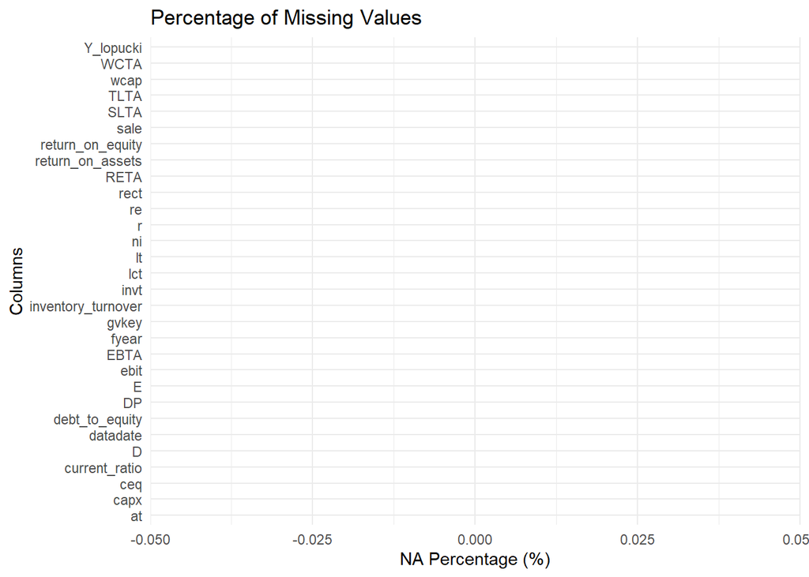

```r
analyze_na(data)
```

```r
# Estimate equity volatility (sig_E) using historical returns
data <- data %>%
  group_by(gvkey) %>%
  arrange(datadate) %>%
  mutate(
    log_ret = ifelse(!is.na(lag(E)) & lag(E) > 0 & E > 0, log(E / lag(E)), NA)
, # Handle invalid values
    sig_E = ifelse(sum(!is.na(log_ret)) >= 60, sd(log_ret, na.rm = TRUE) * sqrt(252), NA)
  ) %>%
  ungroup()
```

```r
# Naïve Distance to Default (DtD_naive)
data <- data %>%
  mutate(
    sigma_D = 0.05 + 0.25 * sig_E, # Approximation for debt volatility
    sigma_V = ifelse(!is.na(E) & !is.na(D) & E + D > 0 & sigma_D > 0,
                     (E / (E + D)) * sig_E + (D / (E + D)) * sigma_D, NA),
    T = 1, # 1-year horizon
    r = ifelse(is.na(r), 0.01, r), # Fill missing risk-free rates with a default value
    DtD_naive = ifelse(!is.na(sigma_V) & sigma_V > 0 & D > 0 & E + D > 0,
                       (log((E + D) / D) + (r - 0.5 * sigma_V^2) * T) / (sigma_V * sqrt(T)), NA),
    PD_naive = ifelse(!is.na(DtD_naive), pnorm(-DtD_naive), NA)
  )
```

```r
# PDF-Based Function for Iterative DtD Calculation
iterative_dtd_pdf <- function(data) {
  T <- 1
  iter_max <- 15
  tol <- 1e-4

  data <- data %>%
    filter(!is.na(E) & !is.na(D) & E > 0 & D > 0 & sig_E > 0) %>%
    mutate(
      V = E + D, # Initial asset value
      sig_V = sig_E * E / (E + D), # Initial asset volatility
      converged = FALSE, # Convergence flag
      iter = 0 # Iteration counter
    )

  for (i in 1:iter_max) {
    data <- data %>%
      mutate(
        d1 = (log(V / D) + (r + 0.5 * sig_V^2) * T) / (sig_V * sqrt(T)),
        d2 = d1 - sig_V * sqrt(T),
        V_new = (E + D * exp(-r * T) * pnorm(d2)) / pnorm(d1),
        sig_V_new = sd(log(V_new / lag(V_new, default = V_new[1])), na.rm = TRUE) * sqrt(252),
        error = abs(sig_V - sig_V_new),
        sig_V = ifelse(error < tol, sig_V, sig_V_new),
        V = ifelse(error < tol, V, V_new),
        converged = error < tol | converged,
        iter = iter + 1
      )
    if (all(data$converged)) break
  }

  data <- data %>%
    mutate(
      DtD = (log(V / D) + (r - 0.5 * sig_V^2) * T) / (sig_V * sqrt(T)),
      PD = pnorm(-DtD)
    ) %>%
    dplyr::select(gvkey, datadate, DtD, PD)

  return(data)
}
```

```r
# Apply iterative DtD function using PDF method
iterative_results <- iterative_dtd_pdf(data)

# Join results back to the original dataset
data <- data %>%
  left_join(iterative_results, by = c("gvkey", "datadate"), relationship = "many-to-many") %>%
  dplyr::rename(DtD_iterative = DtD, PD_iterative = PD)

# Summary statistics
summary_results <- data %>%
  summarise(
    Naive_Mean_DtD = mean(DtD_naive, na.rm = TRUE),
    Iterative_Mean_DtD = mean(DtD_iterative, na.rm = TRUE),
    Naive_Mean_PD = mean(PD_naive, na.rm = TRUE),
    Iterative_Mean_PD = mean(PD_iterative, na.rm = TRUE)
  )
print(summary_results)
```

```
# A tibble: 1 × 4
  Naive_Mean_DtD Iterative_Mean_DtD Naive_Mean_PD Iterative_Mean_PD
           <dbl>              <dbl>         <dbl>             <dbl>
1          -3.34              -17.7         0.929                 1
```

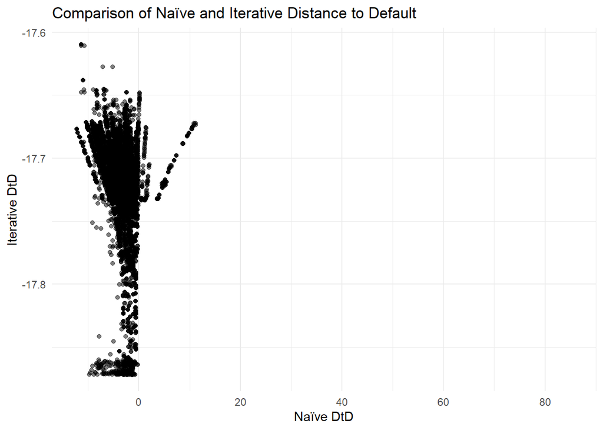

```r
# Plot comparison of Naïve and Iterative DtD
ggplot(data, aes(x = DtD_naive, y = DtD_iterative)) +
  geom_point(alpha = 0.5) +
  geom_abline(slope = 1, intercept = 0, color = "red") +
  labs(
    title = "Comparison of Naïve and Iterative Distance to Default",
    x = "Naïve DtD",
    y = "Iterative DtD"
  ) +
  theme_minimal()
```

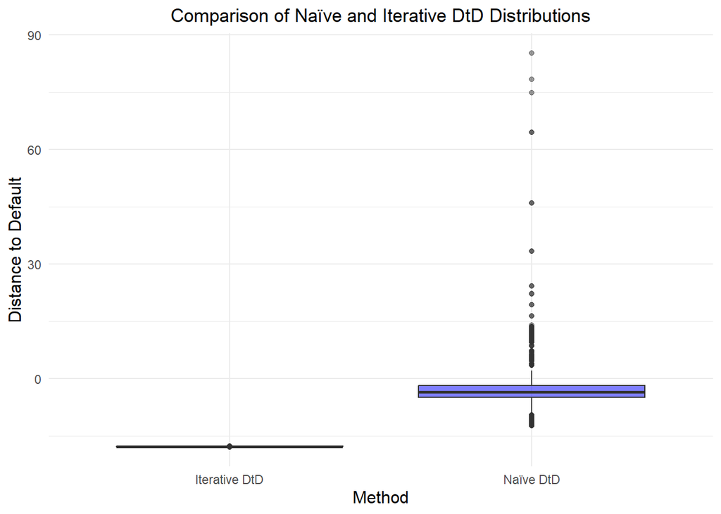

```r
ggplot(data) +
  geom_boxplot(aes(x = "Naïve DtD", y = DtD_naive), fill = "blue", alpha = 0.5) +
  geom_boxplot(aes(x = "Iterative DtD", y = DtD_iterative), fill = "red", alpha = 0.5) +
  labs(
    title = "Comparison of Naïve and Iterative DtD Distributions",
    x = "Method",
    y = "Distance to Default"
  ) +
  theme_minimal() +
  theme(
    plot.title = element_text(hjust = 0.5),
    axis.title = element_text(size = 12)
  )
```

The box plot provides a distributional comparison of the Naïve and Iterative DtD values. Naïve DtD shows a broad range with significant positive values, as well as several outliers above 10. This reflects that the naïve approach often estimates a larger distance to default, potentially overstating financial stability. Iterative DtD has a much narrower distribution, tightly centered around a value near -17.7. This suggests that the iterative method consistently estimates companies as being much closer to default compared to the naïve method.

We now want to add several macro-level predictors: (i) revenue Growth; (ii) Asset growth. (iii) Change in Leverage - change in the dept to equity ratio from the previous year.

```r
# Add macro predictors
data <- data %>%
  group_by(gvkey) %>%
  arrange(datadate) %>%
  mutate(
    revenue_growth = (sale - lag(sale)) / lag(sale),        # Revenue growth
    asset_growth = (at - lag(at)) / lag(at),               # Asset growth
    leverage_change = debt_to_equity - lag(debt_to_equity) # Change in leverage
  ) %>%
  ungroup()
```

Then, we add micro predictors (company-specific/ related to the stock price and returns). They include (i) Rolling volatility: rolling window of 60 periods to calculate the standard deviation of the log returns. This represents the measure of a stock price volatility over the past 60 periods. (ii) Momentum (3months): a rolling sum of the log returns over 60 periods.

After this, we fit the logistic regression to the new predictors.

```r
# Micro variables
data <- data %>%
  group_by(gvkey) %>%
  arrange(datadate) %>%
  mutate(
    rolling_volatility = rollapply(log_ret, width = 60, FUN = sd, fill = NA, align = "right"), # Rolling volatility
    momentum_3m = rollapply(log_ret, width = 60, FUN = sum, fill = NA, align = "right") # 3-month momentum
  ) %>%
  ungroup()
```

```r
# Fit logistic regression with new predictors
model <- glm(Y_lopucki ~ DtD_naive + revenue_growth + asset_growth + rolling_volatility + momentum_3m,
             data = data,
             family = "binomial")

# Summarize the model
summary(model)
```

```
Call:
glm(formula = Y_lopucki ~ DtD_naive + revenue_growth + asset_growth +
    rolling_volatility + momentum_3m, family = "binomial", data = data)

Coefficients:
                   Estimate Std. Error z value Pr(>|z|)
(Intercept)        -4.65986    0.15361 -30.336   <2e-16 ***
DtD_naive           0.34403    0.02835  12.134   <2e-16 ***
revenue_growth      0.02020    0.02548   0.793   0.4278
asset_growth       -0.08474    0.45257  -0.187   0.8515
rolling_volatility  2.38459    0.13854  17.212   <2e-16 ***
momentum_3m        -0.03907    0.01929  -2.025   0.0429 *
---
Signif. codes:  0 '***' 0.001 '**' 0.01 '*' 0.05 '.' 0.1 ' ' 1

(Dispersion parameter for binomial family taken to be 1)

    Null deviance: 1676.7  on 7210  degrees of freedom
Residual deviance: 1214.8  on 7205  degrees of freedom
  (342601 observations effacées parce que manquantes)
AIC: 1226.8

Number of Fisher Scoring iterations: 8
```

**DtD_naive (0.34, p < 2e-16):** This variable has a positive and significant effect on the likelihood of default. A one-unit increase in DtD_naive is associated with an increase in the log-odds of default, contrary to its usual interpretation as a measure of financial stability. This result may warrant further investigation.

**Revenue Growth (0.02, p = 0.42):** Revenue growth is not statistically significant, suggesting it does not have a strong direct relationship with the likelihood of default in this model.

**Asset Growth (-0.08, p = 0.85):** Similarly, asset growth is not a significant predictor, indicating no strong evidence of its impact on default probability.

**Rolling Volatility (2.38, p < 2e-16):** This variable is highly significant and positively associated with default risk. Increased rolling volatility, indicating higher stock price variability, corresponds to a higher likelihood of default.

**Momentum_3m (-0.03, p = 0.04):** Momentum over the past three months has a significant negative effect on the probability of default. This suggests that stronger recent momentum reduces the likelihood of default.

The model identifies DtD_naive, rolling_volatility, and momentum_3m as significant predictors of default. High rolling volatility emerges as a strong indicator of financial distress, while recent positive momentum appears protective against default risk. The insignificance of revenue and asset growth may indicate that short-term changes in these metrics are less relevant in predicting default, compared to variables capturing volatility and trends.

```r
# Predict probabilities
data <- data %>%
  mutate(predicted_prob = predict(model, newdata = data, type = "response"))

# Assess model performance
roc_curve <- roc(data$Y_lopucki, data$predicted_prob)
auc(roc_curve)
```

```
Area under the curve: 0.9115
```

An AUC (Area Under the Curve) value of 0.91 indicates that the model performs well in distinguishing between companies that default and those that do not.

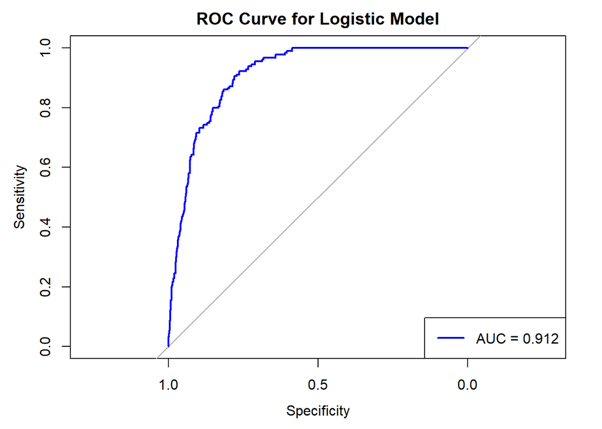

```r
# Generate ROC curve
roc_curve <- roc(data$Y_lopucki, data$predicted_prob, quiet = TRUE)

# Plot the ROC curve
plot(roc_curve, col = "blue", lwd = 2, main = "ROC Curve for Logistic Model")

# Add AUC (Area Under the Curve) to the plot
auc_value <- auc(roc_curve)
legend("bottomright", legend = paste("AUC =", round(auc_value, 3)), col = "blue", lwd = 2)
```

# Practical 3 - Lasso / Gradient Boosted Trees

## Lasso Implementation

```r
# Normalization
normalize <- function(x) {
  if (!is.na(sd(x, na.rm = TRUE)) && sd(x, na.rm = TRUE) > 0) {
    (x - mean(x, na.rm = TRUE)) / sd(x, na.rm = TRUE)
  } else {
    x
  }
}

data <- df_selected %>%
  mutate(across(
    .cols = where(is.numeric) & !c(Y_lopucki,fyear),
    .fns = normalize
  ))

data$Y_lopucki <- df_selected$Y_lopucki
```

```r
numeric_data <- data %>% select(where(is.numeric), -Y_lopucki)
cor_matrix <- cor(numeric_data, use = "pairwise.complete.obs")
```

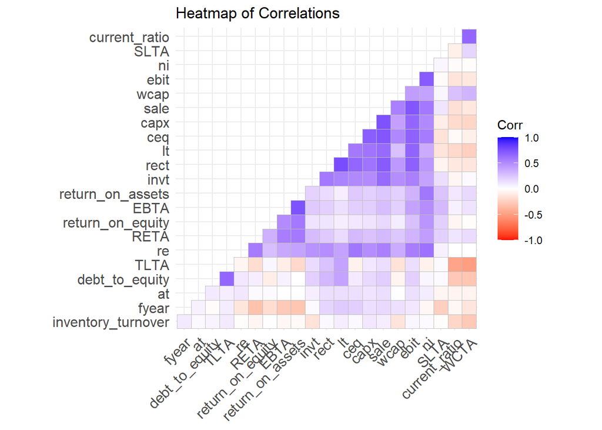

```r
# Heatmap of the correlation matrix
ggcorrplot(cor_matrix,
           hc.order = TRUE,
           type = "lower",
           colors = c("red", "white", "blue")) +
  ggtitle("Heatmap of Correlations")
```

```r
# Select all columns except those in exclude_cols
X <- as.matrix(data %>% select(where(is.numeric), -Y_lopucki))
Y <- as.factor(data$Y_lopucki)

scaled_data <- scale(X)
```

### Lasso Model

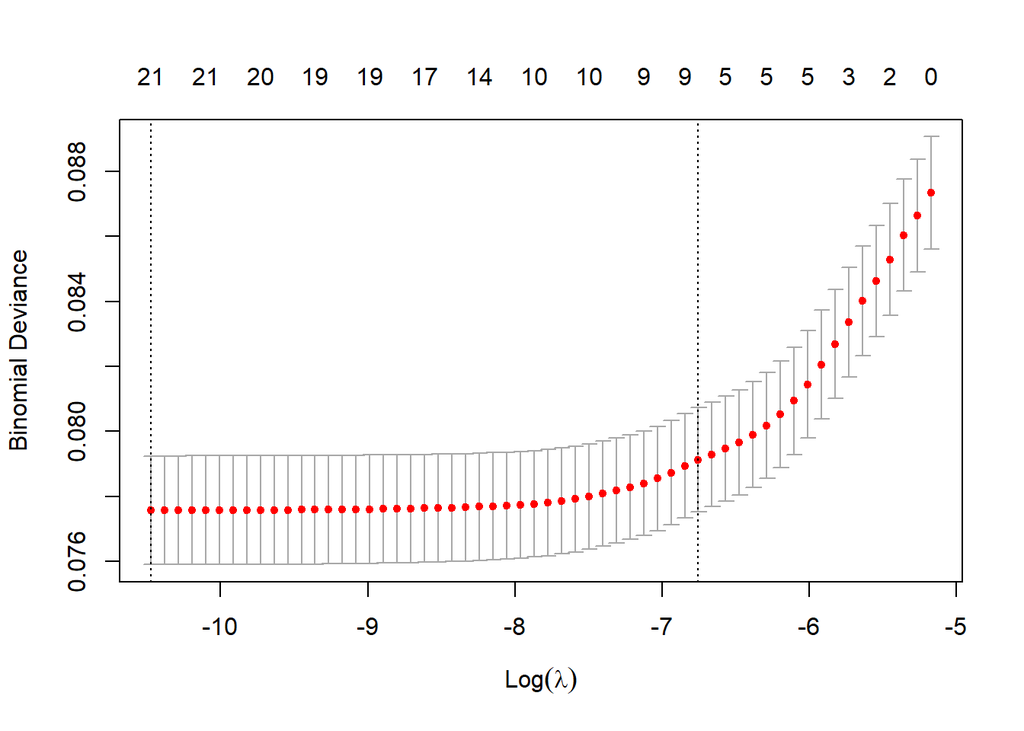

```r
set.seed(123)
# Perform cross-validated Lasso
lasso_cv <- cv.glmnet(scaled_data, Y, alpha = 1, family = "binomial")

plot(lasso_cv)
```

```r
# Get the best lambda
best_lambda <- lasso_cv$lambda.min
print(best_lambda) # 3.167693e-05
```

```
[1] 2.825802e-05
```

```r
# final Lasso model
lasso_model <- glmnet(scaled_data, Y, alpha = 1, lambda = best_lambda, family = "binomial", maxit=200000)
```

This code uses cross-validation to find the best penalty parameter (lambda) for a Lasso logistic regression model. The function `cv.glmnet()` tests multiple lambda values to identify the one that minimizes the error. The plot shows the binomial deviance for each lambda, with the dashed line marking the best lambda. The selected lambda, stored as `best_lambda`, is then used to fit the final Lasso model. This ensures the model focuses on the most important predictors while avoiding overfitting.

### Feature Selection

```r
# Selected predictors
selected_predictors <- colnames(X)[which(coef(lasso_model) != 0)]
print(selected_predictors)
```

```
 [1] "inventory_turnover" "current_ratio"      "ebit"
 [4] "EBTA"               "wcap"               "WCTA"
 [7] "invt"               "capx"               "re"
[10] "RETA"               "debt_to_equity"     "return_on_equity"
[13] "ceq"                "lt"                 "TLTA"
[16] "ni"                 "return_on_assets"   "sale"
[19] "SLTA"               "at"                 "fyear"
[22] NA
```

```r
coef(lasso_model)
```

```
23 x 1 sparse Matrix of class "dgCMatrix"
                             s0
(Intercept)        -5.522683578
inventory_turnover -0.022914079
current_ratio       .
rect               -0.009197804
ebit               -0.183241679
EBTA               -0.033031721
wcap               -0.059593900
WCTA               -0.153846656
invt                0.134378075
capx               -0.017837930
re                 -0.311692423
RETA                0.062572268
debt_to_equity     -0.025798455
return_on_equity    0.023688342
ceq                -0.315969032
lt                  0.554157027
TLTA                0.169857153
ni                 -0.350675842
return_on_assets   -0.396235963
sale                0.292865182
SLTA                0.028782209
at                  0.022746845
fyear               0.048089058
```

The printed coefficients show the contribution of each variable to the model. Positive coefficients (e.g., `lt`, `sale`, `TLTA`) indicate a positive association with the target, while negative coefficients (e.g., `ebit`, `ni`, `return_on_assets`) indicate a negative relationship.

### Relaxed and Thresholded Lasso

```r
relaxed_model <- glmnet(
  x = X,
  y = Y,
  alpha = 0.5,  # Between Ridge (0) and Lasso (1)
  lambda = best_lambda,
  family = "binomial"
)
```

```r
coef(relaxed_model)
```

```
23 x 1 sparse Matrix of class "dgCMatrix"
                              s0
(Intercept)        -12.780028490
inventory_turnover  -0.025372865
current_ratio        0.001012553
rect                -0.014072588
ebit                -0.184630293
EBTA                -0.036534587
wcap                -0.062251510
WCTA                -0.155846063
invt                 0.136330544
capx                -0.023274102
re                  -0.314077087
RETA                 0.068733632
debt_to_equity      -0.028519367
return_on_equity     0.024221097
ceq                 -0.316263115
lt                   0.557311436
TLTA                 0.171599456
ni                  -0.351368953
return_on_assets    -0.395682395
sale                 0.299304004
SLTA                 0.030112558
at                   0.023684552
fyear                0.003643280
```

This code demonstrates the use of a **relaxed Lasso model**, which combines the properties of Ridge (alpha = 0) and Lasso (alpha = 1) regression by setting `alpha = 0.5`. This hybrid approach allows for some coefficients to be shrunk towards zero while retaining a level of flexibility to include correlated predictors that might be excluded by Lasso alone.

```r
threshold <- 0.01
thresholded_variables <- selected_predictors[
  abs(coef(lasso_model)[-1]) > threshold
]
print(thresholded_variables)
```

```
 [1] "inventory_turnover" "EBTA"               "wcap"
 [4] "WCTA"               "invt"               "capx"
 [7] "re"                 "RETA"               "debt_to_equity"
[10] "return_on_equity"   "ceq"                "lt"
[13] "TLTA"               "ni"                 "return_on_assets"
[16] "sale"               "SLTA"               "at"
[19] "fyear"              NA
```

### Address Class Imbalance

```r
class_weights <- ifelse(Y == 1, 10, 1)

lasso_model_weighted <- glmnet(
  x = X,
  y = Y,
  alpha = 1,
  lambda = best_lambda,
  family = "binomial",
  weights = class_weights
)

lasso_model_weighted
```

```
Call:  glmnet(x = X, y = Y, family = "binomial", weights = class_weights,      alpha = 1, lambda = best_lambda)

  Df  %Dev    Lambda
1 22 16.03 2.826e-05
```

This code applies class weighting in the Lasso logistic regression model to handle imbalanced datasets.

## Adjusting Financial Variables by Firm Size

### Data Preparation

```r
# Adjusting Financial Variables by Firm Size
df <- data %>%
  mutate(
    size = pmax(debt_to_equity, at, na.rm = TRUE),  # Firm size as max(debt-to-equity, total assets)
    WCTA_adj = WCTA / size,                        # Adjust WCTA by firm size
    RETA_adj = RETA / size,                        # Adjust RETA by firm size
    EBTA_adj = EBTA / size,                        # Adjust EBTA by firm size
    TLTA_adj = TLTA / size,                        # Adjust TLTA by firm size
    SLTA_adj = SLTA / size                         # Adjust SLTA by firm size
  )
```

### Lasso model

```r
# Prepare data for Lasso model
X <- model.matrix(Y_lopucki ~ WCTA_adj + RETA_adj + EBTA_adj + TLTA_adj + SLTA_adj, data = df)[, -1]
y <- df$Y_lopucki

# Fit Lasso model
set.seed(123)  # For reproducibility
lasso_model <- cv.glmnet(X, y, alpha = 1, family = "binomial")

# Optimal lambda value
optimal_lambda <- lasso_model$lambda.min
cat("Optimal Lambda:", optimal_lambda, "\n")
```

```
Optimal Lambda: 0.0001151543
```

```r
# Coefficients of the Lasso model
lasso_coefs <- coef(lasso_model, s = "lambda.min")
print(lasso_coefs)
```

```
6 x 1 sparse Matrix of class "dgCMatrix"
                       s1
(Intercept) -4.898829e+00
WCTA_adj     .
RETA_adj     .
EBTA_adj     .
TLTA_adj    -2.446401e-05
SLTA_adj     .
```

This code implements a Lasso logistic regression model that adjusts financial variables by firm size to account for differences in scale. The financial ratios (`WCTA`, `RETA`, `EBTA`, `TLTA`, `SLTA`) are normalized by dividing each by the firm’s size, calculated as the maximum of `debt_to_equity` and `total_assets`. This ensures that the variables are comparable across firms of different sizes.

A Lasso regression is then fitted using cross-validation (`cv.glmnet`) to identify the optimal regularization parameter (`lambda.min`) that minimizes the model’s binomial deviance. The coefficients of the model at this optimal lambda are extracted, showing which variables contribute most significantly to the predictions.

### Cross Validation (Time Series)

```r
# Define a time-series split
time_control <- trainControl(
  method = "timeslice",
  initialWindow = 100,
  horizon = 20,
  fixedWindow = TRUE
)

lasso_cv <- train(
  x = X,
  y = Y,
  method = "glmnet",
  trControl = time_control,
  tuneGrid = expand.grid(alpha = 1, lambda = seq(0.01, 0.1, by = 0.01))
)
```

### Evaluation Model

```r
pred_probs <- predict(lasso_model, newx = X_test, type = "response")
relaxed_probs <- predict(relaxed_model, newx = X_test[, thresholded_vars], type = "response")

lasso_auc <- auc(roc(Y_test, pred_probs))
relaxed_auc <- auc(roc(Y_test, relaxed_probs))

print(paste("Lasso AUC:", lasso_auc))
print(paste("Relaxed Lasso AUC:", relaxed_auc))
```

## Gradient Boosted Trees (GBT)

### Prepare the Data

```r
set.seed(123)  # For reproducibility
train_index <- createDataPartition(data$Y_lopucki, p = 0.8, list = FALSE)
train_data <- data[train_index, ]
test_data <- data[-train_index, ]
```

```r
X_test <- as.matrix(test_data %>% select(-c(Y_lopucki,fyear,gvkey)))
Y_test <- test_data$Y_lopucki

X_train <- as.matrix(train_data %>% select(-c(Y_lopucki,fyear,gvkey)))
Y_train <- train_data$Y_lopucki

dtrain <- xgb.DMatrix(data = X_train, label = Y_train)
dtest <- xgb.DMatrix(data = X_test, label = Y_test)
```

### Set Up Hyperparameter Grid

```r
params <- list(
  objective = "binary:logistic",
  eval_metric = "auc",
  eta = 0.01,
  max_depth = 3,
  subsample = 0.8,
  colsample_bytree = 0.8,
  min_child_weight = 10
)
```

### Cross-Validation

```r
# Cross-validation to find optimal nrounds
cv_results <- xgb.cv(
  params = params,
  data = dtrain,
  nfold = 5,                 # 5-fold cross-validation
  nrounds = 300,             # Test up to 300 trees
  early_stopping_rounds = 10, # Stop if no improvement after 10 rounds
  maximize = TRUE,
  verbose = 1
)
```

[output not shown]

```r
# Optimal number of rounds
best_nrounds <- cv_results$best_iteration
print(paste("Optimal number of rounds:", best_nrounds))
```

```
[1] "Optimal number of rounds: 208"
```

### XGBoost

```r
# Train the final model
xgb_model <- xgb.train(
  params = params,
  data = dtrain,
  nrounds = best_nrounds,   # Use optimal nrounds from cross-validation
  watchlist = list(train = dtrain, eval = dtest),
  early_stopping_rounds = 10,
  print_every_n = 10
)
```

[output not shown]

### Evaluate the model

```r
# Predict probabilities
pred_probs <- predict(xgb_model, newdata = dtest)

# Evaluate AUC
roc_curve <- roc(Y_test, pred_probs)
auc_value <- auc(roc_curve)

print(paste("AUC on test data:", auc_value))
```

```
[1] "AUC on test data: 0.789645720623144"
```

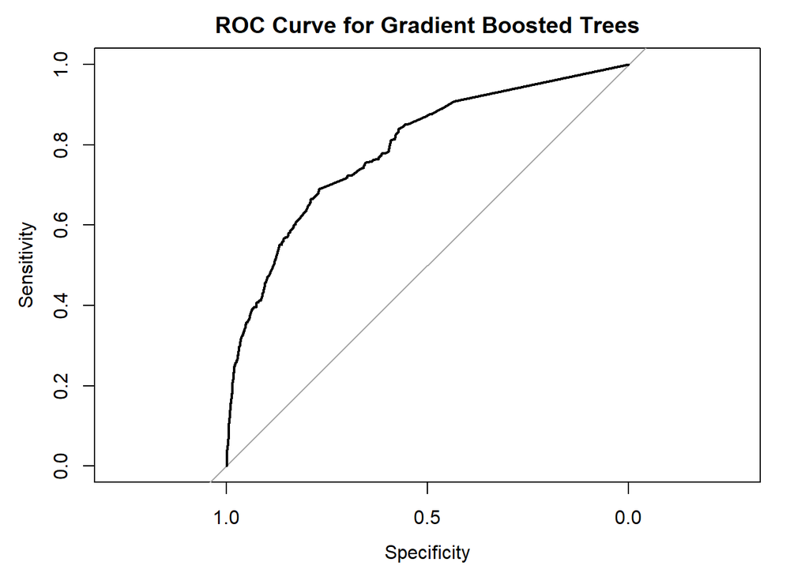

```r
# Plot ROC Curve
plot(roc_curve, main = "ROC Curve for Gradient Boosted Trees")
```

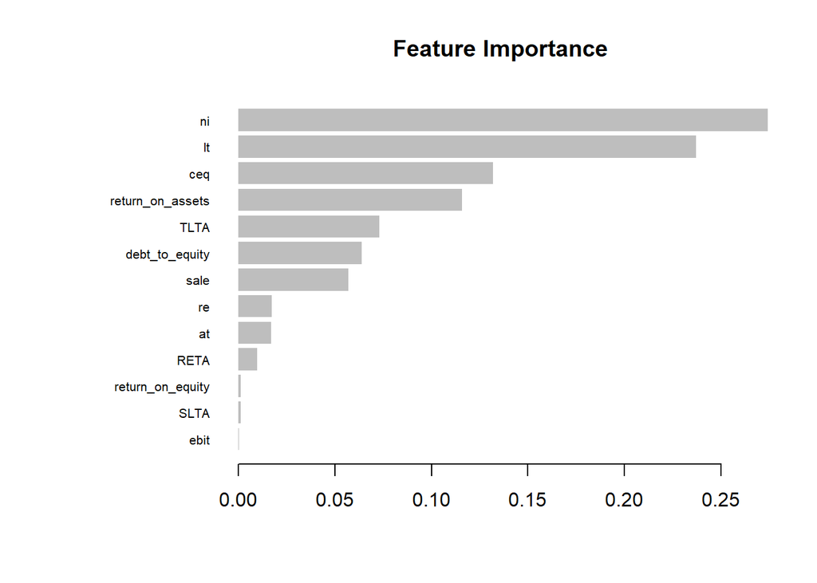

```r
importance <- xgb.importance(model = xgb_model, feature_names = colnames(X_train))
xgb.plot.importance(importance, main = "Feature Importance")
```

The **feature importance plot** highlights the most influential predictors used by the model. Variables like `ni`, `lt`, and `return_on_asset`are among the most important features, suggesting that they contribute significantly to the model’s predictions. This insight can guide future analysis by emphasizing these key features.

### Bonus :

#### Random Search for Hyperparameter Tuning

```r
set.seed(123)

# Define a random hyperparameter space
n_samples <- 20  # Number of random combinations to test
random_params <- data.frame(
  eta = runif(n_samples, 0.01, 0.1),
  max_depth = sample(2:6, n_samples, replace = TRUE),
  subsample = runif(n_samples, 0.6, 1),
  colsample_bytree = runif(n_samples, 0.6, 1),
  min_child_weight = sample(1:10, n_samples, replace = TRUE)
)

# Initialize variables to track the best parameters
best_auc <- 0
best_params <- list()

# Random search loop
for (i in 1:n_samples) {
  params <- list(
    objective = "binary:logistic",
    eval_metric = "auc",
    eta = random_params$eta[i],
    max_depth = random_params$max_depth[i],
    subsample = random_params$subsample[i],
    colsample_bytree = random_params$colsample_bytree[i],
    min_child_weight = random_params$min_child_weight[i]
  )

  # Train using xgb.cv
  cv_results <- xgb.cv(
    params = params,
    data = dtrain,
    nfold = 5,
    nrounds = 300,
    early_stopping_rounds = 10,
    verbose = 0
  )

  # Extract the best AUC
  current_auc <- max(cv_results$evaluation_log$test_auc_mean)

  # Update the best parameters if this combination is better
  if (current_auc > best_auc) {
    best_auc <- current_auc
    best_params <- params
  }
}

print(paste("Best AUC:", best_auc))
print("Best Parameters:")
print(best_params)
```

#### Bayesian Optimization

```r
# Define the scoring function for optimization
scoring_function <- function(eta, max_depth, subsample, colsample_bytree, min_child_weight) {
  params <- list(
    objective = "binary:logistic",
    eval_metric = "auc",
    eta = eta,
    max_depth = as.integer(max_depth),
    subsample = subsample,
    colsample_bytree = colsample_bytree,
    min_child_weight = min_child_weight
  )

  cv_results <- xgb.cv(
    params = params,
    data = dtrain,
    nfold = 5,
    nrounds = 300,
    early_stopping_rounds = 10,
    verbose = 0
  )

  # Return the maximum AUC as the score to maximize
  max(cv_results$evaluation_log$test_auc_mean)
}

# Run Bayesian optimization
set.seed(123)
bayes_results <- bayesOpt(
  FUN = scoring_function,
  bounds = list(
    eta = c(0.01, 0.1),
    max_depth = c(2L, 6L),
    subsample = c(0.6, 1),
    colsample_bytree = c(0.6, 1),
    min_child_weight = c(1, 10)
  ),
  initPoints = 10,
  iters.n = 20,
  acq = "ei"
)

# Best parameters from Bayesian optimization
print(bayes_results$scoreSummary)
```

#### Early Stopping for Efficient Training

```r
xgb_model <- xgb.train(
  params = best_params,
  data = dtrain,
  nrounds = 500,
  watchlist = list(train = dtrain, eval = dtest),
  early_stopping_rounds = 10,  # Stop if no improvement for 10 rounds
  print_every_n = 10
)
```

## Bonus : LDA

```r
#install.packages("MASS")
library(MASS)
df_selected <- subset(df_selected, select = -fyear)
df_selected$Y <- as.factor(df_selected$Y_lopucki)
set.seed(123)
# Separate the data into the majority and minority classes
majority_class <- df_selected %>% filter(Y_lopucki == 0)  # Non-default (majority)
minority_class <- df_selected %>% filter(Y_lopucki == 1)  # Default (minority)

# Undersample the majority class to match the minority class
undersampled_majority <- majority_class %>% sample_n(nrow(minority_class))
data <- bind_rows(undersampled_majority, minority_class)

index <- createDataPartition(df_selected$Y, p = 0.7, list = FALSE)
train_data <- df_selected[index, ]
test_data <- df_selected[-index, ]
```

### 2. Remove of constant variables. LDA requires variablility

```r
# We have one constant variable, we need to remove this to perform LDA. As LDA requires variablility
# Identify variables that are constant within groups
constant_vars <- sapply(train_data[-which(names(train_data) == "Y")], function(col) {
  length(unique(col[train_data$Y == 0])) == 1 && length(unique(col[train_data$Y == 1])) == 1
})

# Output names of constant variables
constant_cols <- names(constant_vars[constant_vars])
print(constant_cols)
```

```
[1] "Y_lopucki"
```

```r
# Drop constant columns from the dataset
train_data <- train_data[, !names(train_data) %in% constant_cols]
```

### 3. Get Rid of Colinearity

```r
# We have high colinearity.
# Calculate the correlation matrix for numeric variables
# Filter numeric columns and compute the correlation matrix
numeric_data <- train_data %>%
  select_if(is.numeric)  # Select only numeric columns

cor_matrix <- cor(numeric_data, use = "pairwise.complete.obs")

# Find pairs of variables with high correlation (e.g., |correlation| > 0.9)
high_corr_pairs <- which(abs(cor_matrix) > 0.5, arr.ind = TRUE)
high_corr_pairs <- high_corr_pairs[high_corr_pairs[, 1] < high_corr_pairs[, 2], ]

# Identify variables to drop (keep only one variable from each highly correlated pair)
vars_to_drop <- unique(colnames(cor_matrix)[high_corr_pairs[, 2]])

# Drop collinear variables from train and test datasets
train_data <- train_data[, !(names(train_data) %in% vars_to_drop)]

test_data <- test_data[, !(names(test_data) %in% vars_to_drop)]

# Ensure the test dataset matches the train dataset
train_vars <- names(train_data)

test_data <- test_data[, names(test_data) %in% train_vars]
```

### 4. Train the model on the numeric dataset

```r
numeric_cols <- sapply(train_data, is.numeric) # Logical vector of numeric columns
numeric_cols["Y"] <- TRUE

train_data_numeric <- train_data[, numeric_cols]
test_data_numeric <- test_data[, numeric_cols]


lda_model <- lda(Y ~ ., data = train_data_numeric)
print(lda_model)
```

```
Call:
lda(Y ~ ., data = train_data_numeric)

Prior probabilities of groups:
          0           1
0.992598315 0.007401685

Group means:
  inventory_turnover current_ratio     rect         EBTA     wcap
0           7.230774      2.137915 28.64569  0.036409735 17.21513
1           7.600729      1.837027 35.52428 -0.002914823 13.73886
  debt_to_equity      SLTA       at
0       1.430385 0.9833400 1525.740
1       1.689728 0.9456433 2358.563

Coefficients of linear discriminants:
                             LD1
inventory_turnover -4.859780e-03
current_ratio      -2.254547e-01
rect                1.571071e-02
EBTA               -9.711459e+00
wcap               -1.321040e-02
debt_to_equity      1.539471e-01
SLTA                2.772980e-01
at                 -1.095281e-06
```

The coefficients of the linear discriminant (LD1) reveal the relative importance of each financial variable in distinguishing between groups in the dataset. The variable `EBTA` has the largest negative coefficient (-9.71), indicating it is the most significant predictor and has a strong negative influence on the discriminant function. Conversely, `SLTA` has the highest positive coefficient (0.28), suggesting it positively contributes to group differentiation. Other variables, such as `debt_to_equity` (0.15) and rect (0.016), also show a positive influence, but their contributions are smaller. Variables like `current_ratio` (-0.22), `inventory_turnover` (-0.005), and `wcap` (-0.01) have negative coefficients, meaning they negatively impact the separation between groups, although their effects are relatively minor compared to `EBTA`. These results suggest that `EBTA` and `SLTA` play a key role in driving the distinction between the groups in the analysis.

### 5. Get Predictions

```r
lda_predictions <- predict(lda_model, newdata = test_data_numeric)
predicted_classes <- lda_predictions$class  # Predicted classes (Y = 0 or Y = 1)
```

### 6. Assesment

```r
# Evaluate model performance
# Confusion Matrix
conf_matrix <- confusionMatrix(predicted_classes, test_data_numeric$Y)
print(conf_matrix)
```

```
Confusion Matrix and Statistics

          Reference
Prediction      0      1
         0 102417    763
         1      0      0

               Accuracy : 0.9926
                 95% CI : (0.9921, 0.9931)
    No Information Rate : 0.9926
    P-Value [Acc > NIR] : 0.5096

                  Kappa : 0

 Mcnemar's Test P-Value : <2e-16

            Sensitivity : 1.0000
            Specificity : 0.0000
         Pos Pred Value : 0.9926
         Neg Pred Value :    NaN
             Prevalence : 0.9926
         Detection Rate : 0.9926
   Detection Prevalence : 1.0000
      Balanced Accuracy : 0.5000

       'Positive' Class : 0
```

```r
# Accuracy
accuracy <- conf_matrix$overall['Accuracy']
cat("Accuracy:", accuracy)
```

```
Accuracy: 0.9926052
```